# Risk Factor Analysis

## Outcome Variable

**Outcome Variable:** haz

## Predictor Variables

**Intervention Variable:** mage

**Adjustment Set:**

- arm
- meducyrs
- feducyrs
- W_mhtcm
- single
- impsan
- W_gagebrth
- W_birthwt
- W_birthlen
- vagbrth
- parity
- delta_meducyrs
- delta_feducyrs
- delta_W_mhtcm
- delta_single
- delta_impsan
- delta_W_gagebrth
- delta_W_birthwt
- delta_W_birthlen
- delta_vagbrth
- delta_parity

## Stratifying Variables

The analysis was stratified on these variable(s):

- agecat
- studyid
- country

## Data Summary

| agecat | studyid | country | mage | n_cell | n |
| --- | --- | --- | --- | --- | --- |
| 6 months | ki0047075b-MAL-ED | BANGLADESH | [20-30) | 165 | 241 |
| 6 months | ki0047075b-MAL-ED | BANGLADESH | <20 | 35 | 241 |
| 6 months | ki0047075b-MAL-ED | BANGLADESH | >=30 | 41 | 241 |
| 6 months | ki0047075b-MAL-ED | BRAZIL | [20-30) | 125 | 209 |
| 6 months | ki0047075b-MAL-ED | BRAZIL | <20 | 37 | 209 |
| 6 months | ki0047075b-MAL-ED | BRAZIL | >=30 | 47 | 209 |
| 6 months | ki0047075b-MAL-ED | INDIA | [20-30) | 179 | 234 |
| 6 months | ki0047075b-MAL-ED | INDIA | <20 | 34 | 234 |
| 6 months | ki0047075b-MAL-ED | INDIA | >=30 | 21 | 234 |
| 6 months | ki0047075b-MAL-ED | NEPAL | [20-30) | 185 | 236 |
| 6 months | ki0047075b-MAL-ED | NEPAL | <20 | 5 | 236 |
| 6 months | ki0047075b-MAL-ED | NEPAL | >=30 | 46 | 236 |
| 6 months | ki0047075b-MAL-ED | PERU | [20-30) | 136 | 273 |
| 6 months | ki0047075b-MAL-ED | PERU | <20 | 76 | 273 |
| 6 months | ki0047075b-MAL-ED | PERU | >=30 | 61 | 273 |
| 6 months | ki0047075b-MAL-ED | SOUTH AFRICA | [20-30) | 118 | 254 |
| 6 months | ki0047075b-MAL-ED | SOUTH AFRICA | <20 | 42 | 254 |
| 6 months | ki0047075b-MAL-ED | SOUTH AFRICA | >=30 | 94 | 254 |
| 6 months | ki0047075b-MAL-ED | TANZANIA, UNITED REPUBLIC OF | [20-30) | 128 | 247 |
| 6 months | ki0047075b-MAL-ED | TANZANIA, UNITED REPUBLIC OF | <20 | 15 | 247 |
| 6 months | ki0047075b-MAL-ED | TANZANIA, UNITED REPUBLIC OF | >=30 | 104 | 247 |
| 6 months | ki1000108-CMC-V-BCS-2002 | INDIA | [20-30) | 293 | 369 |
| 6 months | ki1000108-CMC-V-BCS-2002 | INDIA | <20 | 33 | 369 |
| 6 months | ki1000108-CMC-V-BCS-2002 | INDIA | >=30 | 43 | 369 |
| 6 months | ki1000108-IRC | INDIA | [20-30) | 342 | 407 |
| 6 months | ki1000108-IRC | INDIA | <20 | 36 | 407 |
| 6 months | ki1000108-IRC | INDIA | >=30 | 29 | 407 |
| 6 months | ki1000109-EE | PAKISTAN | [20-30) | 159 | 370 |
| 6 months | ki1000109-EE | PAKISTAN | <20 | 1 | 370 |
| 6 months | ki1000109-EE | PAKISTAN | >=30 | 210 | 370 |

[output cut: 114 more lines]

The following strata were considered:

- agecat: 24 months, studyid: ki0047075b-MAL-ED, country: BANGLADESH
- agecat: 24 months, studyid: ki0047075b-MAL-ED, country: BRAZIL
- agecat: 24 months, studyid: ki0047075b-MAL-ED, country: INDIA
- agecat: 24 months, studyid: ki0047075b-MAL-ED, country: NEPAL
- agecat: 24 months, studyid: ki0047075b-MAL-ED, country: PERU
- agecat: 24 months, studyid: ki0047075b-MAL-ED, country: SOUTH AFRICA
- agecat: 24 months, studyid: ki0047075b-MAL-ED, country: TANZANIA, UNITED REPUBLIC OF
- agecat: 24 months, studyid: ki1000108-CMC-V-BCS-2002, country: INDIA
- agecat: 24 months, studyid: ki1000108-IRC, country: INDIA
- agecat: 24 months, studyid: ki1017093-NIH-Birth, country: BANGLADESH
- agecat: 24 months, studyid: ki1017093b-PROVIDE, country: BANGLADESH
- agecat: 24 months, studyid: ki1017093c-NIH-Crypto, country: BANGLADESH
- agecat: 24 months, studyid: ki1066203-TanzaniaChild2, country: TANZANIA, UNITED REPUBLIC OF
- agecat: 24 months, studyid: ki1101329-Keneba, country: GAMBIA
- agecat: 24 months, studyid: ki1113344-GMS-Nepal, country: NEPAL
- agecat: 24 months, studyid: ki1119695-PROBIT, country: BELARUS
- agecat: 24 months, studyid: ki1126311-ZVITAMBO, country: ZIMBABWE
- agecat: 24 months, studyid: ki1135781-COHORTS, country: GUATEMALA
- agecat: 24 months, studyid: ki1135781-COHORTS, country: INDIA
- agecat: 24 months, studyid: ki1135781-COHORTS, country: PHILIPPINES
- agecat: 24 months, studyid: ki1148112-LCNI-5, country: MALAWI
- agecat: 24 months, studyid: kiGH5241-JiVitA-3, country: BANGLADESH
- agecat: 6 months, studyid: ki0047075b-MAL-ED, country: BANGLADESH
- agecat: 6 months, studyid: ki0047075b-MAL-ED, country: BRAZIL
- agecat: 6 months, studyid: ki0047075b-MAL-ED, country: INDIA
- agecat: 6 months, studyid: ki0047075b-MAL-ED, country: NEPAL
- agecat: 6 months, studyid: ki0047075b-MAL-ED, country: PERU
- agecat: 6 months, studyid: ki0047075b-MAL-ED, country: SOUTH AFRICA
- agecat: 6 months, studyid: ki0047075b-MAL-ED, country: TANZANIA, UNITED REPUBLIC OF
- agecat: 6 months, studyid: ki1000108-CMC-V-BCS-2002, country: INDIA
- agecat: 6 months, studyid: ki1000108-IRC, country: INDIA
- agecat: 6 months, studyid: ki1000109-EE, country: PAKISTAN
- agecat: 6 months, studyid: ki1000304b-SAS-CompFeed, country: INDIA
- agecat: 6 months, studyid: ki1000304b-SAS-FoodSuppl, country: INDIA
- agecat: 6 months, studyid: ki1017093-NIH-Birth, country: BANGLADESH
- agecat: 6 months, studyid: ki1017093b-PROVIDE, country: BANGLADESH
- agecat: 6 months, studyid: ki1017093c-NIH-Crypto, country: BANGLADESH
- agecat: 6 months, studyid: ki1066203-TanzaniaChild2, country: TANZANIA, UNITED REPUBLIC OF
- agecat: 6 months, studyid: ki1101329-Keneba, country: GAMBIA
- agecat: 6 months, studyid: ki1112895-Guatemala BSC, country: GUATEMALA
- agecat: 6 months, studyid: ki1113344-GMS-Nepal, country: NEPAL
- agecat: 6 months, studyid: ki1119695-PROBIT, country: BELARUS
- agecat: 6 months, studyid: ki1126311-ZVITAMBO, country: ZIMBABWE
- agecat: 6 months, studyid: ki1135781-COHORTS, country: GUATEMALA
- agecat: 6 months, studyid: ki1135781-COHORTS, country: INDIA
- agecat: 6 months, studyid: ki1135781-COHORTS, country: PHILIPPINES
- agecat: 6 months, studyid: ki1148112-LCNI-5, country: MALAWI
- agecat: 6 months, studyid: kiGH5241-JiVitA-3, country: BANGLADESH

### Dropped Strata

Some strata were dropped due to rare outcomes:

- agecat: 6 months, studyid: ki1000109-EE, country: PAKISTAN
- agecat: 24 months, studyid: ki0047075b-MAL-ED, country: NEPAL
- agecat: 24 months, studyid: ki1066203-TanzaniaChild2, country: TANZANIA, UNITED REPUBLIC OF

## Methods Detail

We’re interested in the causal parameters $E[Y_a]$ for all values of $a \in \mathcal{A}$. These parameters represent the mean outcome if, possibly contrary to fact, we intervened to set all units to have $A=a$. Under the randomization and positivity assumptions, these are identified by the statistical parameters $\psi_a=E_W[E_{Y|A,W}(Y|A=a,W)]$. In addition, we’re interested in the mean of $Y$, $E[Y]$ under no intervention (the observed mean). We will estimate these parameters by using SuperLearner to fit the relevant likelihood factors – $E_{Y|A,W}(Y|A=a,W)$ and $p(A=a|W)$, and then updating our likelihood fit using a joint TMLE.

For unadjusted analyses ($W=\{\}$), initial likelihoods were estimated using Lrnr_glm to estimate the simple $E(Y|A)$ and Lrnr_mean to estimate $p(A)$. For adjusted analyses, a small library containing Lrnr_glmnet, Lrnr_xgboost, and Lrnr_mean was used.

Having estimated these parameters, we will then use the delta method to estimate relative risks and attributable risks relative to a prespecified baseline level of $A$.

# Results Detail

## Results Plots

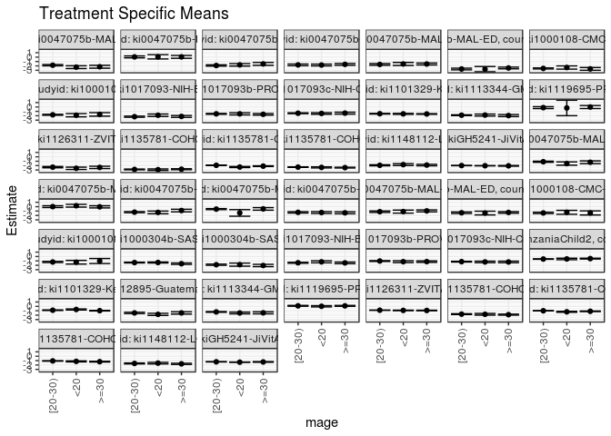

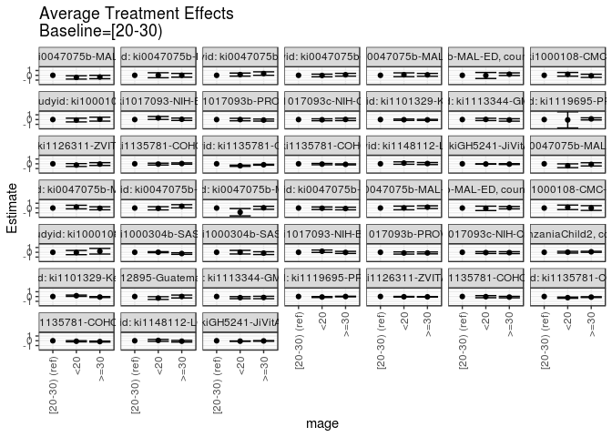

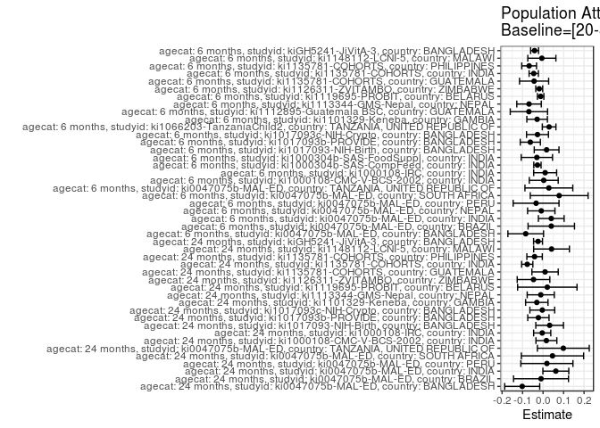

## Results Table

### Parameter: TSM

| agecat | studyid | country | intervention_level | baseline_level | estimate | ci_lower | ci_upper |
| --- | --- | --- | --- | --- | --- | --- | --- |
| 6 months | ki0047075b-MAL-ED | BANGLADESH | [20-30) | NA | -1.1211337 | -1.2527382 | -0.9895292 |
| 6 months | ki0047075b-MAL-ED | BANGLADESH | <20 | NA | -1.5335480 | -1.9090951 | -1.1580010 |
| 6 months | ki0047075b-MAL-ED | BANGLADESH | >=30 | NA | -1.2392143 | -1.5502356 | -0.9281930 |
| 6 months | ki0047075b-MAL-ED | BRAZIL | [20-30) | NA | 0.0108543 | -0.1925256 | 0.2142341 |
| 6 months | ki0047075b-MAL-ED | BRAZIL | <20 | NA | 0.2153589 | -0.0989303 | 0.5296480 |
| 6 months | ki0047075b-MAL-ED | BRAZIL | >=30 | NA | -0.0370352 | -0.2792284 | 0.2051580 |
| 6 months | ki0047075b-MAL-ED | INDIA | [20-30) | NA | -1.2505349 | -1.3898980 | -1.1111719 |
| 6 months | ki0047075b-MAL-ED | INDIA | <20 | NA | -1.3088935 | -1.6130605 | -1.0047266 |
| 6 months | ki0047075b-MAL-ED | INDIA | >=30 | NA | -0.8844291 | -1.1823748 | -0.5864833 |
| 6 months | ki0047075b-MAL-ED | NEPAL | [20-30) | NA | -0.5523243 | -0.6728895 | -0.4317591 |
| 6 months | ki0047075b-MAL-ED | NEPAL | <20 | NA | -1.4210000 | -2.1753122 | -0.6666878 |
| 6 months | ki0047075b-MAL-ED | NEPAL | >=30 | NA | -0.5027174 | -0.7907851 | -0.2146497 |
| 6 months | ki0047075b-MAL-ED | PERU | [20-30) | NA | -1.2928683 | -1.4505415 | -1.1351952 |
| 6 months | ki0047075b-MAL-ED | PERU | <20 | NA | -1.3363505 | -1.5483296 | -1.1243713 |
| 6 months | ki0047075b-MAL-ED | PERU | >=30 | NA | -1.3950338 | -1.6249309 | -1.1651368 |
| 6 months | ki0047075b-MAL-ED | SOUTH AFRICA | [20-30) | NA | -1.1420788 | -1.3141986 | -0.9699590 |
| 6 months | ki0047075b-MAL-ED | SOUTH AFRICA | <20 | NA | -1.1247456 | -1.4684181 | -0.7810732 |
| 6 months | ki0047075b-MAL-ED | SOUTH AFRICA | >=30 | NA | -0.9596330 | -1.1807169 | -0.7385491 |
| 6 months | ki0047075b-MAL-ED | TANZANIA, UNITED REPUBLIC OF | [20-30) | NA | -1.3884869 | -1.5667590 | -1.2102149 |
| 6 months | ki0047075b-MAL-ED | TANZANIA, UNITED REPUBLIC OF | <20 | NA | -1.4535656 | -1.8762764 | -1.0308549 |
| 6 months | ki0047075b-MAL-ED | TANZANIA, UNITED REPUBLIC OF | >=30 | NA | -1.3130258 | -1.4939686 | -1.1320830 |
| 6 months | ki1000108-CMC-V-BCS-2002 | INDIA | [20-30) | NA | -1.4268301 | -1.5838822 | -1.2697781 |
| 6 months | ki1000108-CMC-V-BCS-2002 | INDIA | <20 | NA | -1.2816233 | -1.7312649 | -0.8319817 |
| 6 months | ki1000108-CMC-V-BCS-2002 | INDIA | >=30 | NA | -1.4240141 | -1.8930621 | -0.9549660 |
| 6 months | ki1000108-IRC | INDIA | [20-30) | NA | -1.2447614 | -1.3884221 | -1.1011008 |
| 6 months | ki1000108-IRC | INDIA | <20 | NA | -1.2964775 | -1.7125065 | -0.8804486 |
| 6 months | ki1000108-IRC | INDIA | >=30 | NA | -1.0230714 | -1.5950693 | -0.4510735 |
| 6 months | ki1000304b-SAS-CompFeed | INDIA | [20-30) | NA | -1.3744575 | -1.4614347 | -1.2874802 |
| 6 months | ki1000304b-SAS-CompFeed | INDIA | <20 | NA | -1.3600578 | -1.4767932 | -1.2433225 |
| 6 months | ki1000304b-SAS-CompFeed | INDIA | >=30 | NA | -1.6368573 | -1.8027190 | -1.4709956 |

[output cut: 105 more lines]

### Parameter: E(Y)

| agecat | studyid | country | intervention_level | baseline_level | estimate | ci_lower | ci_upper |
| --- | --- | --- | --- | --- | --- | --- | --- |
| 6 months | ki0047075b-MAL-ED | BANGLADESH | NA | NA | -1.2056777 | -1.3231497 | -1.0882058 |
| 6 months | ki0047075b-MAL-ED | BRAZIL | NA | NA | 0.0510207 | -0.0930194 | 0.1950608 |
| 6 months | ki0047075b-MAL-ED | INDIA | NA | NA | -1.2105413 | -1.3291476 | -1.0919350 |
| 6 months | ki0047075b-MAL-ED | NEPAL | NA | NA | -0.5610593 | -0.6737915 | -0.4483272 |
| 6 months | ki0047075b-MAL-ED | PERU | NA | NA | -1.3268010 | -1.4351217 | -1.2184802 |
| 6 months | ki0047075b-MAL-ED | SOUTH AFRICA | NA | NA | -1.0633760 | -1.1911088 | -0.9356432 |
| 6 months | ki0047075b-MAL-ED | TANZANIA, UNITED REPUBLIC OF | NA | NA | -1.3601215 | -1.4821830 | -1.2380600 |
| 6 months | ki1000108-CMC-V-BCS-2002 | INDIA | NA | NA | -1.4234508 | -1.5645974 | -1.2823042 |
| 6 months | ki1000108-IRC | INDIA | NA | NA | -1.2344062 | -1.3658524 | -1.1029600 |
| 6 months | ki1000304b-SAS-CompFeed | INDIA | NA | NA | -1.4018563 | -1.4810585 | -1.3226541 |
| 6 months | ki1000304b-SAS-FoodSuppl | INDIA | NA | NA | -1.8986842 | -2.0118892 | -1.7854792 |
| 6 months | ki1017093-NIH-Birth | BANGLADESH | NA | NA | -1.4062134 | -1.4951703 | -1.3172565 |
| 6 months | ki1017093b-PROVIDE | BANGLADESH | NA | NA | -1.0871041 | -1.1635539 | -1.0106543 |
| 6 months | ki1017093c-NIH-Crypto | BANGLADESH | NA | NA | -1.1986783 | -1.2700937 | -1.1272630 |
| 6 months | ki1066203-TanzaniaChild2 | TANZANIA, UNITED REPUBLIC OF | NA | NA | -0.5410317 | -0.5901099 | -0.4919536 |
| 6 months | ki1101329-Keneba | GAMBIA | NA | NA | -0.9040346 | -0.9513522 | -0.8567171 |
| 6 months | ki1112895-Guatemala BSC | GUATEMALA | NA | NA | -1.5617391 | -1.6780690 | -1.4454093 |
| 6 months | ki1113344-GMS-Nepal | NEPAL | NA | NA | -1.3321522 | -1.4103691 | -1.2539352 |
| 6 months | ki1119695-PROBIT | BELARUS | NA | NA | 0.1069986 | 0.0122286 | 0.2017686 |
| 6 months | ki1126311-ZVITAMBO | ZIMBABWE | NA | NA | -0.8900815 | -0.9160782 | -0.8640848 |
| 6 months | ki1135781-COHORTS | GUATEMALA | NA | NA | -1.8157336 | -1.8837688 | -1.7476985 |
| 6 months | ki1135781-COHORTS | INDIA | NA | NA | -1.0441293 | -1.0769738 | -1.0112848 |
| 6 months | ki1135781-COHORTS | PHILIPPINES | NA | NA | -1.1405724 | -1.1824954 | -1.0986493 |
| 6 months | ki1148112-LCNI-5 | MALAWI | NA | NA | -1.6498804 | -1.7271669 | -1.5725940 |
| 6 months | kiGH5241-JiVitA-3 | BANGLADESH | NA | NA | -1.3135466 | -1.3366721 | -1.2904210 |
| 24 months | ki0047075b-MAL-ED | BANGLADESH | NA | NA | -1.9431132 | -2.0691678 | -1.8170586 |
| 24 months | ki0047075b-MAL-ED | BRAZIL | NA | NA | 0.0418343 | -0.1253834 | 0.2090521 |
| 24 months | ki0047075b-MAL-ED | INDIA | NA | NA | -1.8494222 | -1.9760821 | -1.7227624 |
| 24 months | ki0047075b-MAL-ED | PERU | NA | NA | -1.7500995 | -1.8705474 | -1.6296516 |
| 24 months | ki0047075b-MAL-ED | SOUTH AFRICA | NA | NA | -1.6228361 | -1.7581177 | -1.4875546 |
| 24 months | ki0047075b-MAL-ED | TANZANIA, UNITED REPUBLIC OF | NA | NA | -2.6058879 | -2.7403043 | -2.4714714 |
| 24 months | ki1000108-CMC-V-BCS-2002 | INDIA | NA | NA | -2.5593683 | -2.6601027 | -2.4586339 |
| 24 months | ki1000108-IRC | INDIA | NA | NA | -1.7824776 | -1.8765600 | -1.6883952 |
| 24 months | ki1017093-NIH-Birth | BANGLADESH | NA | NA | -2.1826015 | -2.2858082 | -2.0793948 |
| 24 months | ki1017093b-PROVIDE | BANGLADESH | NA | NA | -1.5861179 | -1.6693668 | -1.5028689 |
| 24 months | ki1017093c-NIH-Crypto | BANGLADESH | NA | NA | -1.4295331 | -1.5127726 | -1.3462935 |
| 24 months | ki1101329-Keneba | GAMBIA | NA | NA | -1.5650387 | -1.6150832 | -1.5149942 |
| 24 months | ki1113344-GMS-Nepal | NEPAL | NA | NA | -1.8835905 | -1.9681499 | -1.7990312 |
| 24 months | ki1119695-PROBIT | BELARUS | NA | NA | -0.1314048 | -0.4282725 | 0.1654630 |
| 24 months | ki1126311-ZVITAMBO | ZIMBABWE | NA | NA | -2.4008114 | -2.5160291 | -2.2855938 |
| 24 months | ki1135781-COHORTS | GUATEMALA | NA | NA | -2.8597376 | -2.9241330 | -2.7953421 |
| 24 months | ki1135781-COHORTS | INDIA | NA | NA | -2.0059919 | -2.0454828 | -1.9665010 |
| 24 months | ki1135781-COHORTS | PHILIPPINES | NA | NA | -2.3898650 | -2.4346888 | -2.3450412 |
| 24 months | ki1148112-LCNI-5 | MALAWI | NA | NA | -1.8866737 | -1.9780710 | -1.7952764 |
| 24 months | kiGH5241-JiVitA-3 | BANGLADESH | NA | NA | -2.0127124 | -2.0404582 | -1.9849666 |

### Parameter: ATE

| agecat | studyid | country | intervention_level | baseline_level | estimate | ci_lower | ci_upper |
| --- | --- | --- | --- | --- | --- | --- | --- |
| 6 months | ki0047075b-MAL-ED | BANGLADESH | [20-30) | [20-30) | 0.0000000 | 0.0000000 | 0.0000000 |
| 6 months | ki0047075b-MAL-ED | BANGLADESH | <20 | [20-30) | -0.4124144 | -0.8107931 | -0.0140356 |
| 6 months | ki0047075b-MAL-ED | BANGLADESH | >=30 | [20-30) | -0.1180807 | -0.4561558 | 0.2199945 |
| 6 months | ki0047075b-MAL-ED | BRAZIL | [20-30) | [20-30) | 0.0000000 | 0.0000000 | 0.0000000 |
| 6 months | ki0047075b-MAL-ED | BRAZIL | <20 | [20-30) | 0.2045046 | -0.1689514 | 0.5779606 |
| 6 months | ki0047075b-MAL-ED | BRAZIL | >=30 | [20-30) | -0.0478895 | -0.3639671 | 0.2681882 |
| 6 months | ki0047075b-MAL-ED | INDIA | [20-30) | [20-30) | 0.0000000 | 0.0000000 | 0.0000000 |
| 6 months | ki0047075b-MAL-ED | INDIA | <20 | [20-30) | -0.0583586 | -0.3927948 | 0.2760777 |
| 6 months | ki0047075b-MAL-ED | INDIA | >=30 | [20-30) | 0.3661059 | 0.0374082 | 0.6948035 |
| 6 months | ki0047075b-MAL-ED | NEPAL | [20-30) | [20-30) | 0.0000000 | 0.0000000 | 0.0000000 |
| 6 months | ki0047075b-MAL-ED | NEPAL | <20 | [20-30) | -0.8686757 | -1.6325624 | -0.1047890 |
| 6 months | ki0047075b-MAL-ED | NEPAL | >=30 | [20-30) | 0.0496069 | -0.2626733 | 0.3618872 |
| 6 months | ki0047075b-MAL-ED | PERU | [20-30) | [20-30) | 0.0000000 | 0.0000000 | 0.0000000 |
| 6 months | ki0047075b-MAL-ED | PERU | <20 | [20-30) | -0.0434821 | -0.3085578 | 0.2215936 |
| 6 months | ki0047075b-MAL-ED | PERU | >=30 | [20-30) | -0.1021655 | -0.3808568 | 0.1765259 |
| 6 months | ki0047075b-MAL-ED | SOUTH AFRICA | [20-30) | [20-30) | 0.0000000 | 0.0000000 | 0.0000000 |
| 6 months | ki0047075b-MAL-ED | SOUTH AFRICA | <20 | [20-30) | 0.0173332 | -0.3677536 | 0.4024199 |
| 6 months | ki0047075b-MAL-ED | SOUTH AFRICA | >=30 | [20-30) | 0.1824458 | -0.0983526 | 0.4632442 |
| 6 months | ki0047075b-MAL-ED | TANZANIA, UNITED REPUBLIC OF | [20-30) | [20-30) | 0.0000000 | 0.0000000 | 0.0000000 |
| 6 months | ki0047075b-MAL-ED | TANZANIA, UNITED REPUBLIC OF | <20 | [20-30) | -0.0650787 | -0.5222355 | 0.3920781 |
| 6 months | ki0047075b-MAL-ED | TANZANIA, UNITED REPUBLIC OF | >=30 | [20-30) | 0.0754611 | -0.1779452 | 0.3288674 |
| 6 months | ki1000108-CMC-V-BCS-2002 | INDIA | [20-30) | [20-30) | 0.0000000 | 0.0000000 | 0.0000000 |
| 6 months | ki1000108-CMC-V-BCS-2002 | INDIA | <20 | [20-30) | 0.1452068 | -0.3284923 | 0.6189059 |
| 6 months | ki1000108-CMC-V-BCS-2002 | INDIA | >=30 | [20-30) | 0.0028161 | -0.4894151 | 0.4950472 |
| 6 months | ki1000108-IRC | INDIA | [20-30) | [20-30) | 0.0000000 | 0.0000000 | 0.0000000 |
| 6 months | ki1000108-IRC | INDIA | <20 | [20-30) | -0.0517161 | -0.4900501 | 0.3866179 |
| 6 months | ki1000108-IRC | INDIA | >=30 | [20-30) | 0.2216900 | -0.3674559 | 0.8108359 |
| 6 months | ki1000304b-SAS-CompFeed | INDIA | [20-30) | [20-30) | 0.0000000 | 0.0000000 | 0.0000000 |
| 6 months | ki1000304b-SAS-CompFeed | INDIA | <20 | [20-30) | 0.0143997 | -0.0905388 | 0.1193381 |
| 6 months | ki1000304b-SAS-CompFeed | INDIA | >=30 | [20-30) | -0.2623999 | -0.4240055 | -0.1007943 |

[output cut: 105 more lines]

### Parameter: PAR

| agecat | studyid | country | intervention_level | baseline_level | estimate | ci_lower | ci_upper |
| --- | --- | --- | --- | --- | --- | --- | --- |
| 6 months | ki0047075b-MAL-ED | BANGLADESH | [20-30) | NA | -0.0845441 | -0.1715079 | 0.0024198 |
| 6 months | ki0047075b-MAL-ED | BRAZIL | [20-30) | NA | 0.0401665 | -0.0731106 | 0.1534435 |
| 6 months | ki0047075b-MAL-ED | INDIA | [20-30) | NA | 0.0399936 | -0.0228001 | 0.1027873 |
| 6 months | ki0047075b-MAL-ED | NEPAL | [20-30) | NA | -0.0087350 | -0.0754813 | 0.0580113 |
| 6 months | ki0047075b-MAL-ED | PERU | [20-30) | NA | -0.0339326 | -0.1457672 | 0.0779019 |
| 6 months | ki0047075b-MAL-ED | SOUTH AFRICA | [20-30) | NA | 0.0787028 | -0.0622866 | 0.2196923 |
| 6 months | ki0047075b-MAL-ED | TANZANIA, UNITED REPUBLIC OF | [20-30) | NA | 0.0283655 | -0.0883581 | 0.1450890 |
| 6 months | ki1000108-CMC-V-BCS-2002 | INDIA | [20-30) | NA | 0.0033794 | -0.0670636 | 0.0738223 |
| 6 months | ki1000108-IRC | INDIA | [20-30) | NA | 0.0103552 | -0.0456247 | 0.0663351 |
| 6 months | ki1000304b-SAS-CompFeed | INDIA | [20-30) | NA | -0.0273988 | -0.0451535 | -0.0096441 |
| 6 months | ki1000304b-SAS-FoodSuppl | INDIA | [20-30) | NA | -0.0301269 | -0.1064678 | 0.0462141 |
| 6 months | ki1017093-NIH-Birth | BANGLADESH | [20-30) | NA | 0.0173307 | -0.0430061 | 0.0776675 |
| 6 months | ki1017093b-PROVIDE | BANGLADESH | [20-30) | NA | -0.0621888 | -0.1112773 | -0.0131004 |
| 6 months | ki1017093c-NIH-Crypto | BANGLADESH | [20-30) | NA | -0.0271309 | -0.0805703 | 0.0263086 |
| 6 months | ki1066203-TanzaniaChild2 | TANZANIA, UNITED REPUBLIC OF | [20-30) | NA | 0.0294918 | -0.0038177 | 0.0628013 |
| 6 months | ki1101329-Keneba | GAMBIA | [20-30) | NA | -0.0289735 | -0.0791045 | 0.0211575 |
| 6 months | ki1112895-Guatemala BSC | GUATEMALA | [20-30) | NA | -0.0690591 | -0.1601074 | 0.0219892 |
| 6 months | ki1113344-GMS-Nepal | NEPAL | [20-30) | NA | -0.0684064 | -0.1281361 | -0.0086767 |
| 6 months | ki1119695-PROBIT | BELARUS | [20-30) | NA | -0.0117450 | -0.0275074 | 0.0040173 |
| 6 months | ki1126311-ZVITAMBO | ZIMBABWE | [20-30) | NA | -0.0186724 | -0.0355766 | -0.0017682 |
| 6 months | ki1135781-COHORTS | GUATEMALA | [20-30) | NA | -0.0437588 | -0.1147951 | 0.0272775 |
| 6 months | ki1135781-COHORTS | INDIA | [20-30) | NA | -0.0454242 | -0.0681163 | -0.0227322 |
| 6 months | ki1135781-COHORTS | PHILIPPINES | [20-30) | NA | -0.0679171 | -0.1039452 | -0.0318891 |
| 6 months | ki1148112-LCNI-5 | MALAWI | [20-30) | NA | -0.0059108 | -0.0744626 | 0.0626410 |
| 6 months | kiGH5241-JiVitA-3 | BANGLADESH | [20-30) | NA | -0.0412913 | -0.0605780 | -0.0220045 |
| 24 months | ki0047075b-MAL-ED | BANGLADESH | [20-30) | NA | -0.1016748 | -0.1871179 | -0.0162316 |
| 24 months | ki0047075b-MAL-ED | BRAZIL | [20-30) | NA | -0.0098689 | -0.1438485 | 0.1241108 |
| 24 months | ki0047075b-MAL-ED | INDIA | [20-30) | NA | 0.0623562 | -0.0008308 | 0.1255431 |
| 24 months | ki0047075b-MAL-ED | PERU | [20-30) | NA | 0.0187422 | -0.1083109 | 0.1457953 |
| 24 months | ki0047075b-MAL-ED | SOUTH AFRICA | [20-30) | NA | 0.0461035 | -0.1058841 | 0.1980911 |
| 24 months | ki0047075b-MAL-ED | TANZANIA, UNITED REPUBLIC OF | [20-30) | NA | 0.0988909 | -0.0276113 | 0.2253931 |
| 24 months | ki1000108-CMC-V-BCS-2002 | INDIA | [20-30) | NA | 0.0162816 | -0.0347716 | 0.0673347 |
| 24 months | ki1000108-IRC | INDIA | [20-30) | NA | -0.0040522 | -0.0458904 | 0.0377860 |
| 24 months | ki1017093-NIH-Birth | BANGLADESH | [20-30) | NA | 0.0321250 | -0.0354040 | 0.0996540 |
| 24 months | ki1017093b-PROVIDE | BANGLADESH | [20-30) | NA | -0.0227692 | -0.0747363 | 0.0291978 |
| 24 months | ki1017093c-NIH-Crypto | BANGLADESH | [20-30) | NA | -0.0036690 | -0.0642125 | 0.0568746 |
| 24 months | ki1101329-Keneba | GAMBIA | [20-30) | NA | -0.0305178 | -0.0851579 | 0.0241223 |
| 24 months | ki1113344-GMS-Nepal | NEPAL | [20-30) | NA | -0.0111331 | -0.0773467 | 0.0550804 |
| 24 months | ki1119695-PROBIT | BELARUS | [20-30) | NA | 0.0207443 | -0.1241748 | 0.1656635 |
| 24 months | ki1126311-ZVITAMBO | ZIMBABWE | [20-30) | NA | -0.0465169 | -0.1261058 | 0.0330720 |
| 24 months | ki1135781-COHORTS | GUATEMALA | [20-30) | NA | 0.0097833 | -0.0543734 | 0.0739399 |
| 24 months | ki1135781-COHORTS | INDIA | [20-30) | NA | -0.0771320 | -0.1045334 | -0.0497307 |
| 24 months | ki1135781-COHORTS | PHILIPPINES | [20-30) | NA | -0.0413719 | -0.0790172 | -0.0037265 |
| 24 months | ki1148112-LCNI-5 | MALAWI | [20-30) | NA | 0.0414283 | -0.0457577 | 0.1286142 |
| 24 months | kiGH5241-JiVitA-3 | BANGLADESH | [20-30) | NA | -0.0244664 | -0.0461008 | -0.0028320 |